# Lab 3: Exploratory Data Analysis

Author

Arnav Bhatia

Published

October 2, 2026

Quarto

Running Code

```r
library(leaflet)
library(lubridate)
```

## 1. Read in the data

```r
met <- read.csv("~/Downloads/met_all.gz")
```

The meteorological dataset contains weather-station readings collected from stations in the continental United States.

## 2. Check the dimensions, headers, and footers

```r
dim(met)
```

```
[1] 2377343      30
```

```r
head(met)
```

```
  USAFID  WBAN year month day hour min  lat      lon elev wind.dir wind.dir.qc
1 690150 93121 2019     8   1    0  56 34.3 -116.166  696      220           5
2 690150 93121 2019     8   1    1  56 34.3 -116.166  696      230           5
3 690150 93121 2019     8   1    2  56 34.3 -116.166  696      230           5
4 690150 93121 2019     8   1    3  56 34.3 -116.166  696      210           5
5 690150 93121 2019     8   1    4  56 34.3 -116.166  696      120           5
6 690150 93121 2019     8   1    5  56 34.3 -116.166  696       NA           9
  wind.type.code wind.sp wind.sp.qc ceiling.ht ceiling.ht.qc ceiling.ht.method
1              N     5.7          5      22000             5                 9
2              N     8.2          5      22000             5                 9
3              N     6.7          5      22000             5                 9
4              N     5.1          5      22000             5                 9
5              N     2.1          5      22000             5                 9
6              C     0.0          5      22000             5                 9
  sky.cond vis.dist vis.dist.qc vis.var vis.var.qc temp temp.qc dew.point
1        N    16093           5       N          5 37.2       5      10.6
2        N    16093           5       N          5 35.6       5      10.6
3        N    16093           5       N          5 34.4       5       7.2
4        N    16093           5       N          5 33.3       5       5.0
5        N    16093           5       N          5 32.8       5       5.0
6        N    16093           5       N          5 31.1       5       5.6
  dew.point.qc atm.press atm.press.qc       rh
1            5    1009.9            5 19.88127
2            5    1010.3            5 21.76098
3            5    1010.6            5 18.48212
4            5    1011.6            5 16.88862
5            5    1012.7            5 17.38410
6            5    1012.7            5 20.01540
```

```r
tail(met)
```

```
        USAFID  WBAN year month day hour min    lat      lon elev wind.dir
2377338 726813 94195 2019     8  31   18  56 43.650 -116.633  741       NA
2377339 726813 94195 2019     8  31   19  56 43.650 -116.633  741       70
2377340 726813 94195 2019     8  31   20  56 43.650 -116.633  741       NA
2377341 726813 94195 2019     8  31   21  56 43.650 -116.633  741       10
2377342 726813 94195 2019     8  31   22  56 43.642 -116.636  741       10
2377343 726813 94195 2019     8  31   23  56 43.642 -116.636  741       40
        wind.dir.qc wind.type.code wind.sp wind.sp.qc ceiling.ht ceiling.ht.qc
2377338           9              C     0.0          5      22000             5
2377339           5              N     2.1          5      22000             5
2377340           9              C     0.0          5      22000             5
2377341           5              N     2.6          5      22000             5
2377342           1              N     2.1          1      22000             1
2377343           1              N     2.1          1      22000             1
        ceiling.ht.method sky.cond vis.dist vis.dist.qc vis.var vis.var.qc temp
2377338                 9        N    16093           5       N          5 30.0
2377339                 9        N    16093           5       N          5 32.2
2377340                 9        N    16093           5       N          5 33.3
2377341                 9        N    14484           5       N          5 35.0
2377342                 9        N    16093           1       9          9 34.4
2377343                 9        N    16093           1       9          9 34.4
        temp.qc dew.point dew.point.qc atm.press atm.press.qc       rh
2377338       5      11.7            5    1013.6            5 32.32509
2377339       5      12.2            5    1012.8            5 29.40686
2377340       5      12.2            5    1011.6            5 27.60422
2377341       5       9.4            5    1010.8            5 20.76325
2377342       1       9.4            1    1010.1            1 21.48631
2377343       1       9.4            1    1009.6            1 21.48631
```

## 3. Examine the variables

```r
str(met)
```

```
'data.frame':   2377343 obs. of  30 variables:
 $ USAFID           : int  690150 690150 690150 690150 690150 690150 690150 690150 690150 690150 ...
 $ WBAN             : int  93121 93121 93121 93121 93121 93121 93121 93121 93121 93121 ...
 $ year             : int  2019 2019 2019 2019 2019 2019 2019 2019 2019 2019 ...
 $ month            : int  8 8 8 8 8 8 8 8 8 8 ...
 $ day              : int  1 1 1 1 1 1 1 1 1 1 ...
 $ hour             : int  0 1 2 3 4 5 6 7 8 9 ...
 $ min              : int  56 56 56 56 56 56 56 56 56 56 ...
 $ lat              : num  34.3 34.3 34.3 34.3 34.3 34.3 34.3 34.3 34.3 34.3 ...
 $ lon              : num  -116 -116 -116 -116 -116 ...
 $ elev             : int  696 696 696 696 696 696 696 696 696 696 ...
 $ wind.dir         : int  220 230 230 210 120 NA 320 10 320 350 ...
 $ wind.dir.qc      : chr  "5" "5" "5" "5" ...
 $ wind.type.code   : chr  "N" "N" "N" "N" ...
 $ wind.sp          : num  5.7 8.2 6.7 5.1 2.1 0 1.5 2.1 2.6 1.5 ...
```

[output cut: 16 more lines]

This output shows the names, data types, and example values of the variables in the dataset.

## 4. Examine the key variables

```r
table(met$year)
```

```
   2019
2377343
```

```r
table(met$day)
```

```
    1     2     3     4     5     6     7     8     9    10    11    12    13
75975 75923 76915 76594 76332 76734 77677 77766 75366 75450 76187 75052 76906
   14    15    16    17    18    19    20    21    22    23    24    25    26
77852 76217 78015 78219 79191 76709 75527 75786 78312 77413 76965 76806 79114
   27    28    29    30    31
79789 77059 71712 74931 74849
```

```r
table(met$hour)
```

```
     0      1      2      3      4      5      6      7      8      9     10
 99434  93482  93770  96703 110504 112128 106235 101985 100310 102915 101880
    11     12     13     14     15     16     17     18     19     20     21
100470 103605  97004  96507  97635  94942  94184 100179  94604  94928  96070
    22     23
 94046  93823
```

```r
summary(met$temp)
```

```
   Min. 1st Qu.  Median    Mean 3rd Qu.    Max.     NAs
 -40.00   19.60   23.50   23.59   27.80   56.00   60089
```

```r
summary(met$elev)
```

```
   Min. 1st Qu.  Median    Mean 3rd Qu.    Max.
  -13.0   101.0   252.0   415.8   400.0  9999.0
```

```r
summary(met$wind.sp)
```

```
   Min. 1st Qu.  Median    Mean 3rd Qu.    Max.     NAs
  0.000   0.000   2.100   2.459   3.600  36.000   79693
```

The elevation variable contains values of 9999.0. Based on the data documentation and the implausibility of this elevation for a weather station in the continental United States, these values appear to represent missing observations. Therefore, they are replaced with `NA`.

```r
met$elev[met$elev == 9999.0] <- NA
summary(met$elev)
```

```
   Min. 1st Qu.  Median    Mean 3rd Qu.    Max.     NAs
    -13     101     252     413     400    4113     710
```

### Highest weather-station elevation

```r
max_elevation <- max(met$elev, na.rm = TRUE)
max_elevation
```

```
[1] 4113
```

### Examine unusually low temperatures

```r
met <- met[is.na(met$temp) | met$temp > -40, ]

met2 <- met[order(met$temp), ]
head(met2)
```

```
        USAFID WBAN year month day hour min    lat    lon elev wind.dir
1203053 722817 3068 2019     8   1    0  56 38.767 -104.3 1838      190
1203055 722817 3068 2019     8   1    1  56 38.767 -104.3 1838      180
1203128 722817 3068 2019     8   3   11  56 38.767 -104.3 1838       NA
1203129 722817 3068 2019     8   3   12  56 38.767 -104.3 1838       NA
1203222 722817 3068 2019     8   6   21  56 38.767 -104.3 1838      280
1203225 722817 3068 2019     8   6   22  56 38.767 -104.3 1838      240
        wind.dir.qc wind.type.code wind.sp wind.sp.qc ceiling.ht ceiling.ht.qc
1203053           5              N     7.2          5         NA             9
1203055           5              N     7.7          5         NA             9
1203128           9              C     0.0          5         NA             9
1203129           9              C     0.0          5         NA             9
1203222           5              N     2.6          5         NA             9
1203225           5              N     7.7          5         NA             9
        ceiling.ht.method sky.cond vis.dist vis.dist.qc vis.var vis.var.qc
1203053                 9        N       NA           9       N          5
1203055                 9        N       NA           9       N          5
1203128                 9        N       NA           9       N          5
1203129                 9        N       NA           9       N          5
1203222                 9        N       NA           9       N          5
1203225                 9        N       NA           9       N          5
         temp temp.qc dew.point dew.point.qc atm.press atm.press.qc rh
1203053 -17.2       5        NA            9        NA            9 NA
1203055 -17.2       5        NA            9        NA            9 NA
1203128 -17.2       5        NA            9        NA            9 NA
1203129 -17.2       5        NA            9        NA            9 NA
1203222 -17.2       5        NA            9        NA            9 NA
1203225 -17.2       5        NA            9        NA            9 NA
```

After removing temperatures of −40°C or colder, an observation with a temperature of approximately −17.2°C remains and requires further investigation.

## 5. Check suspicious values

The suspicious temperature observation can be examined using its geographic coordinates and station information.

```r
met[!is.na(met$temp) & met$temp <= -15, ]
```

```
        USAFID  WBAN year month day hour min    lat      lon elev wind.dir
1105455 722518 12974 2019     8  11   23  56 27.901  -98.052   78      150
1105457 722518 12974 2019     8  12    1  56 27.901  -98.052   78      150
1105459 722518 12974 2019     8  12    3  56 27.901  -98.052   78      160
1203053 722817  3068 2019     8   1    0  56 38.767 -104.300 1838      190
1203054 722817  3068 2019     8   1    1   6 38.767 -104.300 1838      180
1203055 722817  3068 2019     8   1    1  56 38.767 -104.300 1838      180
1203128 722817  3068 2019     8   3   11  56 38.767 -104.300 1838       NA
1203129 722817  3068 2019     8   3   12  56 38.767 -104.300 1838       NA
1203221 722817  3068 2019     8   6   21  39 38.767 -104.300 1838      210
1203222 722817  3068 2019     8   6   21  56 38.767 -104.300 1838      280
1203223 722817  3068 2019     8   6   22  32 38.767 -104.300 1838      260
1203224 722817  3068 2019     8   6   22  41 38.767 -104.300 1838       NA
1203225 722817  3068 2019     8   6   22  56 38.767 -104.300 1838      240
1203226 722817  3068 2019     8   6   23   3 38.767 -104.300 1838      210
```

[output cut: 45 more lines]

The unusually low observations were checked against the location and expected climate of the weather station. Because the values were inconsistent with the location and the rest of the dataset, temperatures of −15°C or colder were removed.

```r
met <- met[is.na(met$temp) | met$temp > -15, ]

met2 <- met[order(met$temp), ]
head(met2)
```

```
        USAFID  WBAN year month day hour min    lat      lon elev wind.dir
2370758 726764 94163 2019     8  27   11  50 44.683 -111.116 2025       NA
2370759 726764 94163 2019     8  27   12  10 44.683 -111.116 2025       NA
2370760 726764 94163 2019     8  27   12  30 44.683 -111.116 2025       NA
2370761 726764 94163 2019     8  27   12  50 44.683 -111.116 2025       NA
252489  720411   137 2019     8  18   12  35 36.422 -105.290 2554       NA
2370688 726764 94163 2019     8  26   12  30 44.683 -111.116 2025       NA
        wind.dir.qc wind.type.code wind.sp wind.sp.qc ceiling.ht ceiling.ht.qc
2370758           9              C       0          5      22000             5
2370759           9              C       0          5      22000             5
2370760           9              C       0          5      22000             5
2370761           9              C       0          5      22000             5
252489            9              C       0          5      22000             5
2370688           9              C       0          5      22000             5
        ceiling.ht.method sky.cond vis.dist vis.dist.qc vis.var vis.var.qc temp
2370758                 9        N    16093           5       N          5 -3.0
2370759                 9        N    16093           5       N          5 -3.0
2370760                 9        N    16093           5       N          5 -3.0
2370761                 9        N    16093           5       N          5 -3.0
252489                  9        N    16093           5       N          5 -2.4
2370688                 9        N    16093           5       N          5 -2.0
        temp.qc dew.point dew.point.qc atm.press atm.press.qc       rh
2370758       C      -5.0            C        NA            9 86.26537
2370759       5      -4.0            5        NA            9 92.91083
2370760       5      -4.0            5        NA            9 92.91083
2370761       C      -4.0            C        NA            9 92.91083
252489        5      -3.7            5        NA            9 90.91475
2370688       5      -3.0            5        NA            9 92.96690
```

```r
summary(met$temp)
```

```
   Min. 1st Qu.  Median    Mean 3rd Qu.    Max.     NAs
  -3.00   19.60   23.50   23.59   27.80   56.00   60089
```

## 6. Calculate summary statistics

The next step is to select the observations from the weather station at the maximum elevation.

```r
elev <- met[
  !is.na(met$elev) & met$elev == max(met$elev, na.rm = TRUE),
]

summary(elev)
```

```
     USAFID            WBAN          year          month        day
 Min.   :720385   Min.   :419   Min.   :2019   Min.   :8   Min.   : 1.00
 1st Qu.:720385   1st Qu.:419   1st Qu.:2019   1st Qu.:8   1st Qu.: 8.00
 Median :720385   Median :419   Median :2019   Median :8   Median :16.00
 Mean   :720385   Mean   :419   Mean   :2019   Mean   :8   Mean   :16.07
 3rd Qu.:720385   3rd Qu.:419   3rd Qu.:2019   3rd Qu.:8   3rd Qu.:24.00
 Max.   :720385   Max.   :419   Max.   :2019   Max.   :8   Max.   :31.00

      hour            min            lat            lon              elev
 Min.   : 0.00   Min.   : 6.0   Min.   :39.8   Min.   :-105.8   Min.   :4113
 1st Qu.: 6.00   1st Qu.:14.0   1st Qu.:39.8   1st Qu.:-105.8   1st Qu.:4113
 Median :12.00   Median :36.0   Median :39.8   Median :-105.8   Median :4113
 Mean   :11.61   Mean   :34.6   Mean   :39.8   Mean   :-105.8   Mean   :4113
 3rd Qu.:18.00   3rd Qu.:53.0   3rd Qu.:39.8   3rd Qu.:-105.8   3rd Qu.:4113
 Max.   :23.00   Max.   :59.0   Max.   :39.8   Max.   :-105.8   Max.   :4113

    wind.dir        wind.dir.qc     wind.type.code    wind.sp
 Min.   : 10.0   Length   :2138   Length   :2138   Min.   : 0.000
 1st Qu.:250.0   N.unique :   2   N.unique :   4   1st Qu.: 4.100
 Median :300.0   N.blank  :   0   N.blank  :   0   Median : 6.700
 Mean   :261.5   Min.nchar:   1   Min.nchar:   1   Mean   : 7.245
 3rd Qu.:310.0   Max.nchar:   1   Max.nchar:   1   3rd Qu.: 9.800
 Max.   :360.0                                     Max.   :21.100
 NAs    :258                                       NAs    :189
     wind.sp.qc     ceiling.ht    ceiling.ht.qc   ceiling.ht.method
 Length   :2138   Min.   :   30   Min.   :5.000   Length   :2138
 N.unique :   3   1st Qu.: 2591   1st Qu.:5.000   N.unique :   2
 N.blank  :   0   Median :22000   Median :5.000   N.blank  :   0
 Min.nchar:   1   Mean   :15145   Mean   :5.047   Min.nchar:   1
 Max.nchar:   1   3rd Qu.:22000   3rd Qu.:5.000   Max.nchar:   1
                  Max.   :22000   Max.   :9.000
                  NAs    :25
      sky.cond       vis.dist        vis.dist.qc        vis.var
 Length   :2138   Min.   :    0   Length   :2138   Length   :2138
 N.unique :   2   1st Qu.:16093   N.unique :   3   N.unique :   3
 N.blank  :   0   Median :16093   N.blank  :   0   N.blank  :   0
 Min.nchar:   1   Mean   :15913   Min.nchar:   1   Min.nchar:   1
 Max.nchar:   1   3rd Qu.:16093   Max.nchar:   1   Max.nchar:   1
                  Max.   :16093
                  NAs    :704
     vis.var.qc        temp            temp.qc       dew.point
 Length   :2138   Min.   : 1.00   Length   :2138   Min.   :-6.0000
 N.unique :   2   1st Qu.: 6.00   N.unique :   3   1st Qu.: 0.0000
 N.blank  :   0   Median : 8.00   N.blank  :   0   Median : 0.0000
 Min.nchar:   1   Mean   : 8.13   Min.nchar:   1   Mean   : 0.8729
 Max.nchar:   1   3rd Qu.:10.00   Max.nchar:   1   3rd Qu.: 2.0000
                  Max.   :15.00                    Max.   : 7.0000
                  NAs    :21                       NAs    :21
    dew.point.qc    atm.press     atm.press.qc       rh
 Length   :2138   Min.   : NA    Min.   :9     Min.   :53.63
 N.unique :   3   1st Qu.: NA    1st Qu.:9     1st Qu.:58.10
 N.blank  :   0   Median : NA    Median :9     Median :61.39
 Min.nchar:   1   Mean   :NaN    Mean   :9     Mean   :60.62
 Max.nchar:   1   3rd Qu.: NA    3rd Qu.:9     3rd Qu.:61.85
                  Max.   : NA    Max.   :9     Max.   :70.01
                  NAs    :2138                 NAs    :21
```

### Correlations

```r
cor(elev$temp, elev$wind.sp, use = "complete.obs")
```

```
[1] -0.09373843
```

```r
cor(elev$temp, elev$hour, use = "complete.obs")
```

```
[1] 0.4397261
```

```r
cor(elev$wind.sp, elev$day, use = "complete.obs")
```

```
[1] 0.3643079
```

```r
cor(elev$wind.sp, elev$hour, use = "complete.obs")
```

```
[1] 0.08807315
```

```r
cor(elev$temp, elev$day, use = "complete.obs")
```

```
[1] -0.003857766
```

The correlation between temperature and wind speed indicates whether higher temperatures tend to occur with higher or lower wind speeds. The correlations involving hour and day help identify possible daily and monthly temporal patterns. These correlations should be interpreted cautiously because time variables are cyclical and the relationships may not be linear.

## 7. Exploratory graphs

### Distributions of the key variables

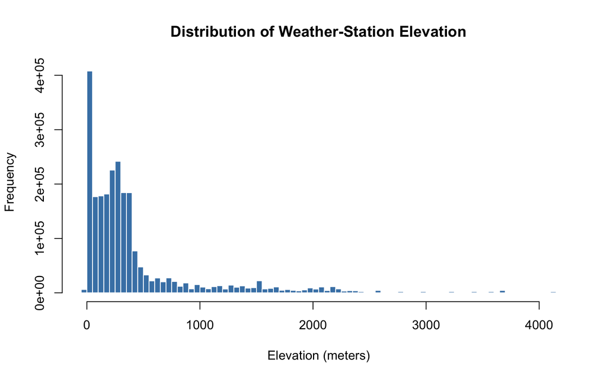

```r
hist(
  met$elev,
  breaks = 100,
  main = "Distribution of Weather-Station Elevation",
  xlab = "Elevation (meters)",
  col = "steelblue",
  border = "white"
)
```

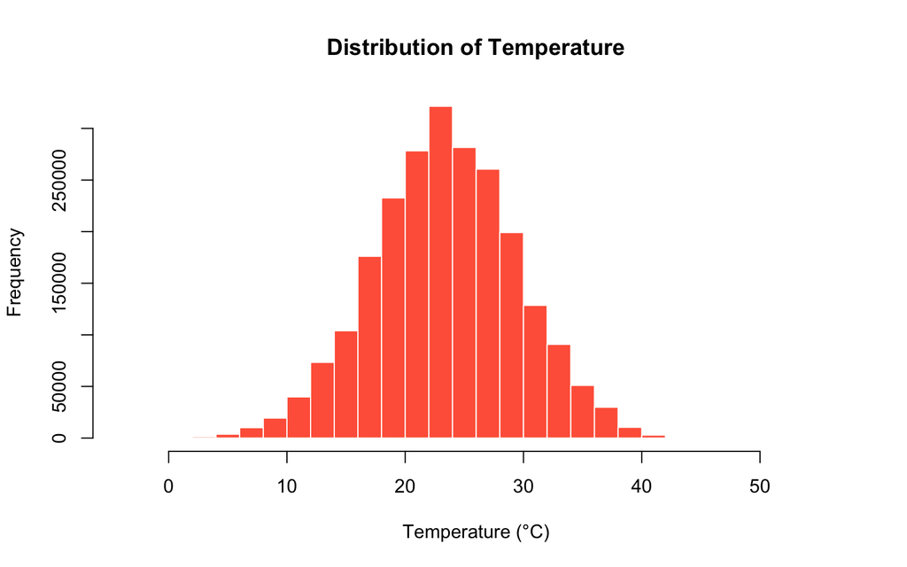

```r
hist(
  met$temp,
  breaks = 30,
  main = "Distribution of Temperature",
  xlab = "Temperature (°C)",
  col = "tomato",
  border = "white"
)
```

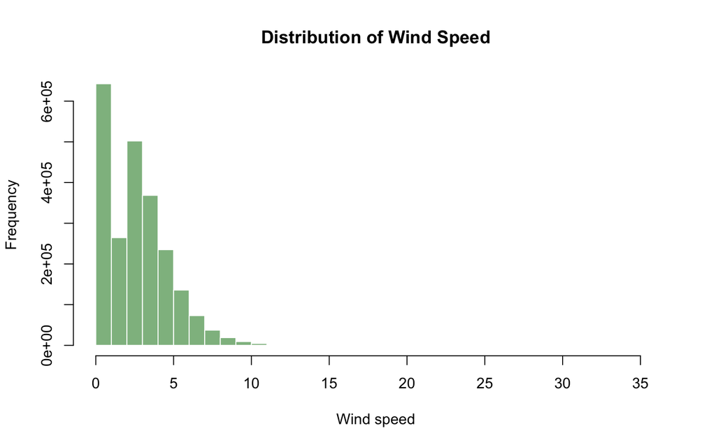

```r
hist(
  met$wind.sp,
  breaks = 30,
  main = "Distribution of Wind Speed",
  xlab = "Wind speed",
  col = "darkseagreen",
  border = "white"
)
```

The distributions of elevation and wind speed appear right-skewed. A log transformation may be useful in a later statistical analysis. However, special care would be required for zero or negative observations before applying a logarithmic transformation.

### Location of the highest-elevation station

```r
leaflet(elev) |>
  addProviderTiles("OpenStreetMap") |>
  addCircles(
    lat = ~lat,
    lng = ~lon,
    opacity = 1,
    fillOpacity = 1,
    radius = 100,
    popup = ~paste(
      "Elevation:", elev, "meters",
      "<br>Latitude:", lat,
      "<br>Longitude:", lon
    )
  )
```

[interactive chart not shown]

The map displays the location of the weather station with the highest recorded elevation.

### Create a date-time variable

```r
elev$date <- with(
  elev,
  ymd_h(paste(year, month, day, hour), tz = "UTC")
)

summary(elev$date)
```

```
                 Min.               1st Qu.                Median
"2019-08-01 00:00:00" "2019-08-08 10:15:00" "2019-08-16 21:00:00"
                 Mean               3rd Qu.                  Max.
"2019-08-16 13:15:37" "2019-08-24 09:00:00" "2019-08-31 22:00:00"
```

```r
elev <- elev[order(elev$date), ]
head(elev)
```

```
       USAFID WBAN year month day hour min  lat      lon elev wind.dir
221697 720385  419 2019     8   1    0  36 39.8 -105.766 4113      170
221698 720385  419 2019     8   1    0  54 39.8 -105.766 4113      100
221699 720385  419 2019     8   1    1  12 39.8 -105.766 4113       90
221700 720385  419 2019     8   1    1  35 39.8 -105.766 4113      110
221701 720385  419 2019     8   1    1  53 39.8 -105.766 4113      120
221702 720385  419 2019     8   1    2  12 39.8 -105.766 4113      120
       wind.dir.qc wind.type.code wind.sp wind.sp.qc ceiling.ht ceiling.ht.qc
221697           5              N     8.8          5       1372             5
221698           5              N     2.6          5       1372             5
221699           5              N     3.1          5       1981             5
221700           5              N     4.1          5       2134             5
221701           5              N     4.6          5       2134             5
221702           5              N     6.2          5      22000             5
       ceiling.ht.method sky.cond vis.dist vis.dist.qc vis.var vis.var.qc temp
```

[output cut: 20 more lines]

### Temperature time series

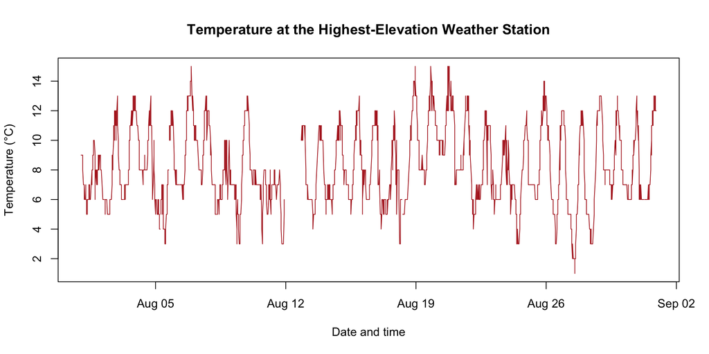

```r
plot(
  elev$date,
  elev$temp,
  type = "l",
  main = "Temperature at the Highest-Elevation Weather Station",
  xlab = "Date and time",
  ylab = "Temperature (°C)",
  col = "firebrick",
  lwd = 1
)
```

### Wind-speed time series

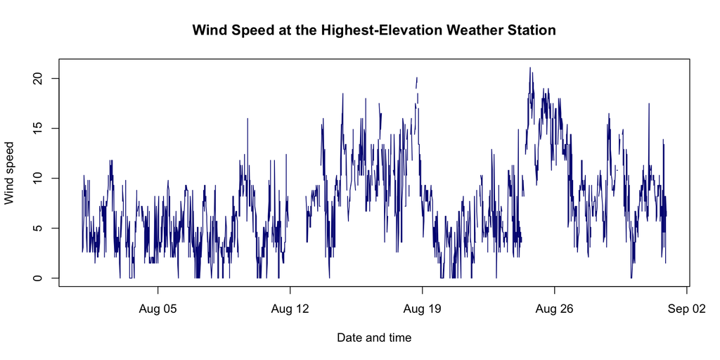

```r
plot(
  elev$date,
  elev$wind.sp,
  type = "l",
  main = "Wind Speed at the Highest-Elevation Weather Station",
  xlab = "Date and time",
  ylab = "Wind speed",
  col = "navy",
  lwd = 1
)
```

### Summary of time-series patterns

The temperature time series shows variation over time, including a daily pattern in which temperatures generally rise during the day and fall during the evening or early morning. The plot may also contain short-term fluctuations caused by changing weather conditions.

Wind speed varies more irregularly over time. It contains periods of relatively low wind speed interrupted by larger peaks. Compared with temperature, wind speed does not appear to follow as smooth or consistent a daily cycle. Missing wind-speed readings may also produce gaps in the plotted line.

## 8. Questions about the data

After examining the dataset, I would ask a collaborator the following questions:

1. What exact value or code is used to indicate missing data for each variable?
2. Why were elevation values of 9999 entered instead of being recorded as missing?
3. What are the measurement units for wind speed?
4. Were all weather stations calibrated using the same procedures and equipment?
5. Are the recorded hours in local time or Coordinated Universal Time?
6. Were the temperature measurements taken at exactly the same time as the wind-speed measurements?
7. Why are there so many missing wind-speed observations?
8. Do multiple rows at the maximum elevation represent one station or several stations at the same elevation?
9. Were any quality-control procedures applied before the dataset was released?
10. Are the unusually low temperature observations measurement errors, coding errors, or valid readings?

## Conclusion

This exploratory analysis identified the weather station with the maximum valid elevation and examined its temperature and wind-speed measurements over time. Elevation values equal to 9999 were treated as missing, and implausibly low temperatures were removed according to the lab instructions. The highest-elevation station displayed temporal variation in both temperature and wind speed, with temperature showing a clearer daily pattern and wind speed showing more irregular fluctuations.